# Assignment4

Hoa Hoang

Monday, April 13, 2020

## Completed: 10/10

## 1. MS 7.118 - pg 364

```r
file = read.csv("NZBIRDS.csv")
```

### a.

```r
sam=dplyr::sample_n(file,35)
sam
```

| Species | Name | Extinct | Habitat | Nest.Site | Nest.Density | Diet | Flight | Body.Mass | Egg.Length |
| --- | --- | --- | --- | --- | --- | --- | --- | --- | --- |
| Waterfowl | A. gracilis | No | A | GC | L | H | Yes | 425 | 50.0 |
| Moas | E. curtus | Yes | TG | G | L | H | No | 20000 | 125.0 |
| Parrots | C. novaezelandiae | No | TA | C | L | H | Yes | 70 | 25.0 |
| Songbirds | T. tanagra | No | TA | A | L | I | Yes | 130 | 35.0 |
| Penguins | M. antipodes | Yes | A | G | L | F | No | 5250 | 77.0 |
| Songbirds | M. novaeseelandiae | No | TA | A | L | I | Yes | 11 | 18.5 |
| Songbirds | P. novaeseelandiae | No | TA | A | L | H | Yes | 90 | 29.0 |
| Songbirds | X. gilviventris | No | TG | A | L | I | Yes | 20 | 20.0 |
| Songbirds | A. novaeseelandiae | No | TG | G | L | I | Yes | 40 | 23.0 |
| Songbirds | B. punctata | No | TG | G | L | I | Yes | 35 | 19.5 |

[output cut: 25 more lines]

### b.

```r
#mean
m=mean(sam$Body.Mass)
m
```

```
## [1] 6810.886
```

```r
#sd
s=sd(sam$Body.Mass)
s
```

```
## [1] 21830.43
```

```r
# 95% CI for mean of body mass
n = 35
a=0.05
left=m-qt(1-a/2,n-1)*(s/sqrt(n))
right=m+qt(1-a/2,n-1)*(s/sqrt(n))
sprintf("%f to %f",left,right)
```

```
## [1] "-688.128577 to 14309.900006"
```

```r
# 95% CI for variance of body mass
left=((n-1)*var(sam$Body.Mass))/qchisq(1-a/2,n-1)
right=((n-1)*var(sam$Body.Mass))/qchisq(a/2,n-1)
sprintf("%f to %f",left,right)
```

```
## [1] "311805777.041366 to 818090002.246806"
```

### d.

The true mean is 9113. The result of part 4 is very likely to be in the 95% CI. Because 95% CI already mean that 95% data lie within the interval.

### e.

```r
#mean
sam
```

| Species | Name | Extinct | Habitat | Nest.Site | Nest.Density | Diet | Flight | Body.Mass | Egg.Length |
| --- | --- | --- | --- | --- | --- | --- | --- | --- | --- |
| Waterfowl | A. gracilis | No | A | GC | L | H | Yes | 425 | 50.0 |
| Moas | E. curtus | Yes | TG | G | L | H | No | 20000 | 125.0 |
| Parrots | C. novaezelandiae | No | TA | C | L | H | Yes | 70 | 25.0 |
| Songbirds | T. tanagra | No | TA | A | L | I | Yes | 130 | 35.0 |
| Penguins | M. antipodes | Yes | A | G | L | F | No | 5250 | 77.0 |
| Songbirds | M. novaeseelandiae | No | TA | A | L | I | Yes | 11 | 18.5 |
| Songbirds | P. novaeseelandiae | No | TA | A | L | H | Yes | 90 | 29.0 |
| Songbirds | X. gilviventris | No | TG | A | L | I | Yes | 20 | 20.0 |
| Songbirds | A. novaeseelandiae | No | TG | G | L | I | Yes | 40 | 23.0 |
| Songbirds | B. punctata | No | TG | G | L | I | Yes | 35 | 19.5 |

[output cut: 25 more lines]

```r
m=mean(sam$Egg.Length)
m
```

```
## [1] 62.74286
```

```r
#sd
s=sd(sam$Egg.Length)
s
```

```
## [1] 45.24547
```

```r
# 95% CI for mean of egg length
n = 35
a = 0.05
left=m-qt(1-a/2,n-1)*(s/sqrt(n))
right=m+qt(1-a/2,n-1)*(s/sqrt(n))
sprintf("%f to %f",left,right)
```

```
## [1] "47.200495 to 78.285220"
```

```r
# 95% CI for variance of egg length
left=((n-1)*s^2)/qchisq(1-a/2,n-1)
right=((n-1)*s^2)/qchisq(a/2,n-1)
sprintf("%f to %f",left,right)
```

```
## [1] "1339.398687 to 3514.202607"
```

For the mean, 95% data is within the calculated range  
For the variance, the numbers are quite big, meaning the value in our sample are far from the mean.

The true mean is 61.06. The result of part 4 is very likely to be in the 95% CI. Because 95% CI already mean that 95% data lie within the interval.

### f.

```r
#1 for non-extinct, 2 for extinct
a=0.05
n1=78
n2=38
p1=7/78
p2=21/38
e1=(p1*(1-p1))/n1
e2=(p2*(1-p2))/n2
left=(p1-p2)-qnorm(1-a/2)*sqrt(e1+e2)
right=(p1-p2)+qnorm(1-a/2)*sqrt(e1+e2)
sprintf("%f to %f",left,right)
```

```
## [1] "-0.633229 to -0.292547"
```

### g.

Since the interval doesn’t include 0 and both of the numbers are negative. The numbers does support the theory

## 2. MS 7.120 - pg 365

```r
#1 for Southern Pine , 2 for Ponderosa Pine
n1=100
n2=47
m1=1312
m2=1352
s1=422
s2=271
a=0.1
```

### a.

```r
#90% CI for the mean different
df=n1+n2-2
e=s1^2/n1+s2^2/n2
left=m1-m2-qnorm(1-a/2)*sqrt(e)
right=m1-m2+qnorm(1-a/2)*sqrt(e)
sprintf("%f to %f",left,right)
```

```
## [1] "-135.109164 to 55.109164"
```

### b.

```r
#90% CI for the variance
# Formula is on page 342
a=0.1
left= (s1^2/s2^2)/qf(1-a/2,n1-1,n2-1)
right= (s1^2/s2^2)*qf(1-a/2,n2-1,n1-1)
sprintf("%f to %f",left,right)
```

```
## [1] "1.566267 to 3.617750"
```

## 3. MS 7.128 - pg 367

### a.

Fact: $z^2$ is identical to $\chi^2$.
Z formula:
$$z=\frac{y-\mu}{\sigma}$$
With mean = 0, we have
$$z=\frac{y}{\sigma}$$
$$z^2=\frac{y^2}{\sigma^2} = \chi^2$$

### b.

$$\chi^2_{0.05/2} \leq \frac{y^2}{\sigma^2} \leq \chi^2_{1-0.05/2}$$
$$\chi^2_{0.05/2} \leq \frac{y^2}{\sigma^2} \leq \chi^2_{1-0.05/2}$$
$$1/ \chi^2_{0.05/2} \leq \frac{\sigma^2}{y^2} \leq 1/ \chi^2_{1-0.05/2}$$
$$y^2/ \chi^2_{0.05/2} \leq \sigma^2 \leq y^2/ \chi^2_{1-0.05/2}$$

## 4. MS 8.24 - pg 390

### a.

$H_0:\mu=2$ $H_a:\mu \neq 2$

### b.

$T = -1.02$ $p = 0.322$

### c.

If p is less than a=0.05, then reject the null hypothesis

### d.

Since p is not less than a=0.05. We don’t reject the null hypothesis

### e.

The 95% CI is (1.635802,2.126198). The null hypothesis, $\mu=2$ is in the interval. We don’t reject it. Since both the confidental interval and t statistic use 95%, they must lead to the same conclustion

## 5. MS 8.28 - pg 392

### a.

$H_0:\mu = 15$ $H_a:\mu \neq 15$

```r
file=read.csv("WISCLAKES.csv")
t.test(file$DOC,mu=15,conf.level = 0.90)
```

```
##
##  One Sample t-test
##
## data:  file$DOC
## t = -0.18668, df = 24, p-value = 0.8535
## alternative hypothesis: true mean is not equal to 15
## 90 percent confidence interval:
##  10.08013 18.95187
## sample estimates:
## mean of x
##    14.516
```

Since p is not less than a=0.1. We don’t reject the null hypothesis

### b.

We must find the rejected regions in term of $\bar y$ $t_{0.95,24}= \pm 1.711$ From table  
For t=-1.711, $\bar y = \mu_0+t(\frac {s}{\sqrt{n}})=15-1.711(\frac{12.96}{\sqrt 5})=10.565$  
For t=-1.711, $\bar y = \mu_0+t(\frac {s}{\sqrt{n}})=15+1.711(\frac{12.96}{\sqrt 5})=19.435$  
Thus, we reject $\bar y < 10.565$ or $\bar y > 19.435$  
$P(t<\frac{10.565-14}{\frac{12.6}{\sqrt 25}})+P(t>\frac{19.435-14}{\frac{12.6}{\sqrt 25}})=0.1212$

The likely hood of detecting the mean equal 14 is 0.1212

## 6. MS 8.44 - pg 40

```r
data=read.csv("ORCHARD.csv")
fog=dplyr::filter(data, CONDITION == "FOG")
clear=dplyr::filter(data, CONDITION == "CLEAR" | CONDITION == "CLOUD")
var.test(fog$RATIO,clear$RATIO)
```

```
##
##  F test to compare two variances
##
## data:  fog$RATIO and clear$RATIO
## F = 0.40455, num df = 7, denom df = 3, p-value = 0.2924
## alternative hypothesis: true ratio of variances is not equal to 1
## 95 percent confidence interval:
##  0.02766288 2.38274359
## sample estimates:
## ratio of variances
##          0.4045529
```

Since p-value = 0.2924 > 0.05, we do not reject the null hypothesis. We will do t.test with var.equal = TRUE

```r
t.test(fog$RATIO,clear$RATIO,var.equal = T)
```

```
##
##  Two Sample t-test
##
## data:  fog$RATIO and clear$RATIO
## t = -2.0467, df = 10, p-value = 0.06788
## alternative hypothesis: true difference in means is not equal to 0
## 95 percent confidence interval:
##  -0.37281919  0.01581919
## sample estimates:
## mean of x mean of y
##   0.27375   0.45225
```

By going with p = 0.06788 > 0.05, and the CI, we can say that the mean not much different

## 7. MS 8.84 - pg 425 This refers to 8.39 NOT 8.33!

### a.

```r
data=read.csv("GASTURBINE.csv")
traditional=dplyr::filter(data, ENGINE == "Traditional")
advanced=dplyr::filter(data, ENGINE =="Advanced")
aero=dplyr::filter(data, ENGINE =="Aeroderiv")
var.test(traditional$HEATRATE,aero$HEATRATE,conf.level = 0.95)
```

```
##
##  F test to compare two variances
##
## data:  traditional$HEATRATE and aero$HEATRATE
## F = 0.23272, num df = 38, denom df = 6, p-value = 0.004234
## alternative hypothesis: true ratio of variances is not equal to 1
## 95 percent confidence interval:
##  0.04635082 0.64308536
## sample estimates:
## ratio of variances
##          0.2327207
```

p = 0.004234 < 0.05 so we reject the null hypothesis. Meaning that the variances are not equal

### b.

```r
var.test(advanced$HEATRATE,aero$HEATRATE,conf.level = 0.95)
```

```
##
##  F test to compare two variances
##
## data:  advanced$HEATRATE and aero$HEATRATE
## F = 0.057974, num df = 20, denom df = 6, p-value = 1.192e-06
## alternative hypothesis: true ratio of variances is not equal to 1
## 95 percent confidence interval:
##  0.0112170 0.1813622
## sample estimates:
## ratio of variances
##         0.05797393
```

p-value = 1.192e-06 which is way smaller than 0.05. We reject the null hypothesis. The variances are not equal

## 8. MS 8.99 - pg 438

```r
data=read.csv("GOBIANTS.csv")
dry=dplyr::filter(data, Region == "Dry Steppe ")
gobi=dplyr::filter(data, Region == "Gobi Desert")
var.test(dry$AntSpecies,gobi$AntSpecies)
```

```
##
##  F test to compare two variances
##
## data:  dry$AntSpecies and gobi$AntSpecies
## F = 1.3684, num df = 4, denom df = 5, p-value = 0.7264
## alternative hypothesis: true ratio of variances is not equal to 1
## 95 percent confidence interval:
##   0.1852264 12.8146380
## sample estimates:
## ratio of variances
##           1.368432
```

We go with the null hypothesis, the variance is equal

```r
t.test(dry$AntSpecies,gobi$AntSpecies,var.equal = T)
```

```
##
##  Two Sample t-test
##
## data:  dry$AntSpecies and gobi$AntSpecies
## t = 0.1821, df = 9, p-value = 0.8595
## alternative hypothesis: true difference in means is not equal to 0
## 95 percent confidence interval:
##  -24.74894  29.08228
## sample estimates:
## mean of x mean of y
##  14.00000  11.83333
```

### a.

$H_0: \mu_1-\mu_2 = 0$  
$H_1: \mu_1-\mu_2 \neq 0$

### b.

t = 0.1821

### c.

We accept (-24.74894, 29.08228) and reject everywhere else.

### d.

p = 0.8595

### e.

p = 0.8595 > 0.05 so we go with the null hypothesis, meaning the mean are not significantly different

### f.

We are assuming the two sample are independent, from normal population

## 9. MS 8.104 - pg 439

```r
data=read.csv("THRUPUT.csv")
t.test(data$HUMAN,data$AUTO,paired=T)
```

```
##
##  Paired t-test
##
## data:  data$HUMAN and data$AUTO
## t = -2.629, df = 7, p-value = 0.03396
## alternative hypothesis: true difference in means is not equal to 0
## 95 percent confidence interval:
##  -61.850346  -3.274654
## sample estimates:
## mean of the differences
##                -32.5625
```

p-value = 0.03396 < 0.05. We conclude that there is a significant different in the mean

## 10.

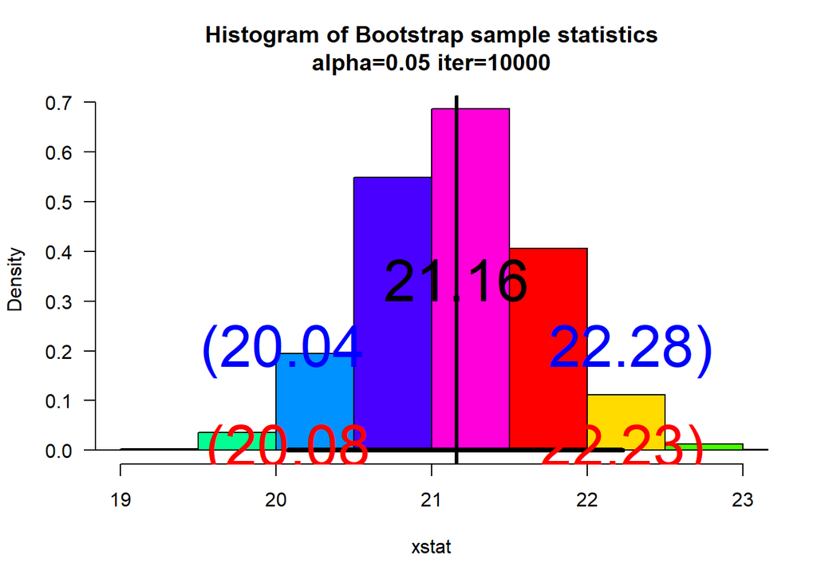

```
## $fun
## [1] "mean"
##
## $x
##  [1] 23.195 20.399 19.898 19.865 30.014 18.821 21.232 18.313 23.574 21.047
## [11] 21.535 21.336 17.695 18.497 14.274 14.664 22.593 18.963 25.515 25.019
## [21] 22.053 22.871 23.006 23.829 19.038 21.735 21.461 21.659 21.703 21.049
##
## $t
## [1] 2.04523
##
## $ci
##     2.5%    97.5%
## 20.07910 22.22545
##
## $cit
## [1] 20.04155 22.28199
```

```r
########### bootstrap function ##################

myboot<-function(iter=10000,x,fun="mean",alpha=0.05,popmean=20,popsd=3,...){  #Notice where the ... is repeated in the code
n=length(x)   #sample size

y=sample(x,n*iter,replace=TRUE)
rs.mat=matrix(y,nr=n,nc=iter,byrow=TRUE)
xstat=apply(rs.mat,2,fun) # xstat is a vector and will have iter values in it
# t score
t=qt(1-alpha/2,df=n-1)
# Ci
ci=quantile(xstat,c(alpha/2,1-alpha/2))
# cit
cit1=mean(x)-t*(popsd/sqrt(n))
cit2=mean(x)+t*(popsd/sqrt(n))
cit=c(cit1,cit2)


# A histogram follows
# The object para will contain the parameters used to make the histogram
para=hist(xstat,breaks=seq(trunc(min(xstat)-1),trunc(max(xstat)+1),0.5),freq=FALSE,las=1,col=rainbow(7),
          xlim=c(trunc(min(xstat)),trunc(max(xstat))),
          main=paste("Histogram of Bootstrap sample statistics","\n","alpha=",alpha," iter=",iter,sep=""),...)

#mat will be a matrix that contains the data, this is done so that I can use apply()
mat=matrix(x,nr=length(x),nc=1,byrow=TRUE)

#pte is the point estimate
#This uses whatever fun is
pte=apply(mat,2,fun)
abline(v=pte,lwd=3,col="Black")# Vertical line
segments(ci[1],0,ci[2],0,lwd=4)      #Make the segment for the ci


text(ci[1],0,paste("(",round(ci[1],2),sep=""),col="Red",cex=3)
text(ci[2],0,paste(round(ci[2],2),")",sep=""),col="Red",cex=3)

text(cit[1],0.2,paste("(",round(cit[1],2),sep=""),col="Blue",cex=3)
text(cit[2],0.2,paste(round(cit[2],2),")",sep=""),col="Blue",cex=3)


# plot the point estimate 1/2 way up the density
text(pte,max(para$density)/2,round(pte,2),cex=3)

return(list(fun=fun,x=x,t=t,ci=ci,cit=cit))# Some output to use if necessary
}
################### END mybooot function #####################
set.seed(35); sam<-round(rnorm(30,mean=20,sd=3),3)
myboot(10000,x=sam,fun = "mean",alpha=0.05,popmean=20,popsd=3)
```